# Reproducible Research -> Peer Assessment

Student of Reproducible Research Coursera Course

Wednesday, May 13, 2015

Revised again 13/06/2015

## Loading and preprocessing the data (Used Windows 7 as OS)

1. Getting the data from the web location indicated

```r
# setInternet2 to TRUE so download.file can works in knitr with https
setInternet2(use = TRUE)
# Took data  from the original source as some issue with length is
# presented when the download is made in R from github location. If you
# have some trouble with the download, please unzip activity.zip in the
## dir you put .Rmd file  and comment next four lines & the unlink(temp)
fileUrl <- "https://d396qusza40orc.cloudfront.net/repdata%2Fdata%2Factivity.zip"
temp <- tempfile()
download.file(fileUrl,temp)
unzip(temp,"activity.csv", list = FALSE, overwrite = TRUE)
dataToUse <- read.csv("activity.csv", header=TRUE,
                      colClasses = c("numeric","Date","integer"))
unlink(temp)
```

2. Removing nulls and converting to use as a Data table

```r
suppressWarnings(library(data.table))
dataToUse <- data.table(dataToUse)
dataToUseNoNulls <- data.table(dataToUse[!is.na(dataToUse$steps),])
```

## What is mean total number of steps taken per day?

1. Calculate the total number of steps taken per day

```r
stepsPerDay <- dataToUseNoNulls[,sum(steps, na.rm=T), by=date]
setnames(stepsPerDay, c("date","steps"))
```

2. Histogram of the total number of steps taken each day

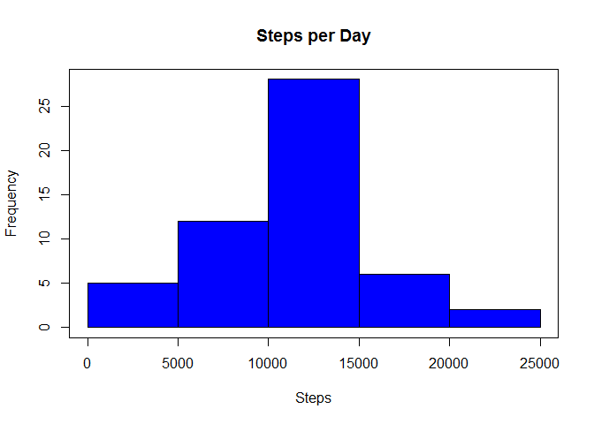

```r
hist(as.numeric(stepsPerDay$steps), c="blue", xlab="Steps", main="Steps per Day")
box()
```

3. Calculating and reporting the mean and median of the total number of steps taken per day

```r
mean(stepsPerDay$steps, na.rm = TRUE)
```

```
## [1] 10766.19
```

```r
median(stepsPerDay$steps, na.rm = TRUE)
```

```
## [1] 10765
```

## What is the average daily activity pattern?

1. Series plot (i.e. type = “l”) of the 5-minute interval (x-axis) and the average number of steps taken, averaged across all days (y-axis)

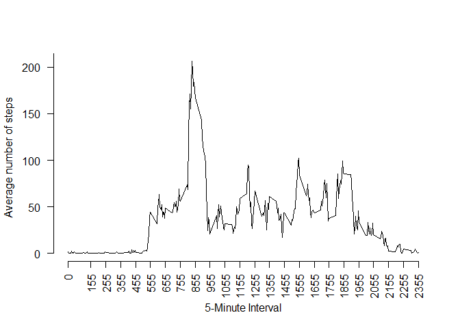

```r
stepsMeanPerInterval <- dataToUseNoNulls[,mean(steps, na.rm=T), by=interval]
setnames(stepsMeanPerInterval, c("interval","steps"))
plot(stepsMeanPerInterval$interval, stepsMeanPerInterval$steps
    , type = "l", axes = F,  ylab = "Average number of steps", xlab = "5-Minute Interval")
axis(side = 1,srt = 45, at = c(0,seq(155,stepsMeanPerInterval$interval[nrow(stepsMeanPerInterval)], by = 100)), las= 3)
axis(side = 2, at = seq(0, 250, by = 50), las=2)
```

2. Which 5-minute interval, on average across all the days in the dataset, contains the maximum number of steps?

```r
## Maximum number of steps
maxNumOfSteps <- max(stepsMeanPerInterval$steps)
maxNumOfSteps
```

```
## [1] 206.1698
```

```r
##  5-minute interval which contains maximun steps
stepsMeanPerInterval[stepsMeanPerInterval$steps == maxNumOfSteps, interval]
```

```
## [1] 835
```

## Imputing missing values

1. Calculating and reporting the total number of missing values in the dataset (i.e. the total number of rows with NAs)

```r
sum(is.na(dataToUse$steps))
```

```
## [1] 2304
```

2. Filling in all of the missing values in the dataset using mean and creating a vector with the filledSteps.

```r
filledSteps <- dataToUse$steps
for (n in 1:nrow(dataToUse)) {
    if (is.na(dataToUse$steps[n])) {
         intervalIndex = stepsMeanPerInterval$interval == dataToUse$interval[n]
         filledSteps[n] = stepsMeanPerInterval$steps[intervalIndex]
    }
}
```

3. Creating a new dataset that is equal to the original dataset but with the missing data filled in steps column

```r
dataToUseFilled <- dataToUse
dataToUseFilled$steps <- filledSteps
```

4. Making a histogram of the total number of steps taken each day and Calculating and reporting the mean and median total number of steps taken per day.

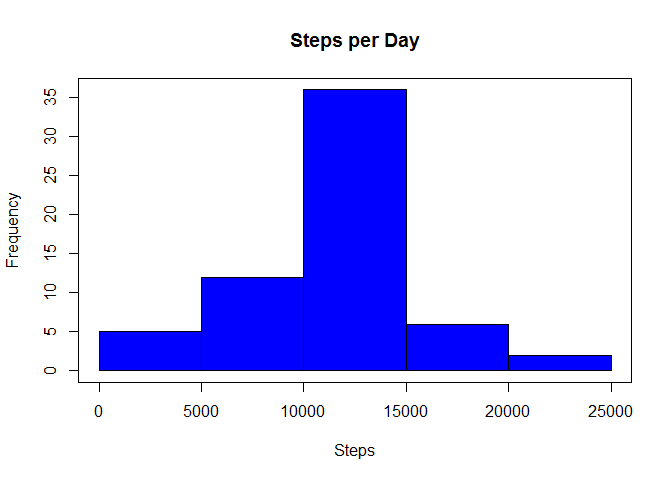

```r
## Steps per Day from the filled data
filledStepsPerDay <- dataToUseFilled[,sum(steps, na.rm=T), by=date]
setnames(filledStepsPerDay, c("date","steps"))

## Histogram of the total number of steps taken each day
hist(filledStepsPerDay$steps, col="blue",xlab="Steps",
     main="Steps per Day")
box()
```

```r
##Calculating and reporting the mean and median total number of steps taken per day
mean(filledStepsPerDay$steps)
```

```
## [1] 10766.19
```

```r
median(filledStepsPerDay$steps)
```

```
## [1] 10766.19
```

## Are there differences in activity patterns between weekdays and weekends?

```r
## Define data day as a weekday or a weekend
## Saturday in day format has value 6 and Sunday has value 7
dataToUseFilled$typeOfDay <- ifelse (format(as.Date(dataToUseFilled$date,
                                                   "%Y-%m-%d"),"%w")
                                     %in%  c(6,7), "Weekend" , "Weekday")

dataToUseFilled$typeOfDay <- as.factor(dataToUseFilled$typeOfDay)
```

2. Making a panel plot containing a time series plot (i.e. type = “l”) of the 5-minute interval (x-axis) and the average number of steps taken, averaged across all weekday days or weekend days (y-axis).

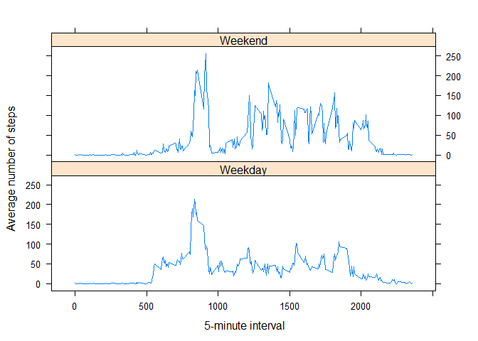

```r
stepsMeanPerIntervalPerWeek <- dataToUseFilled[,mean(steps, na.rm=T),
                                                by=list(typeOfDay,interval)]
setnames(stepsMeanPerIntervalPerWeek, c("typeOfDay","interval","steps"))

library(lattice)
xyplot(stepsMeanPerIntervalPerWeek$steps ~ stepsMeanPerIntervalPerWeek$interval
      | stepsMeanPerIntervalPerWeek$typeOfDay, type = "l", layout = c(1,2),
      xlab = " 5-minute interval", ylab = "Average number of steps")
```